```r
# Load packages
pacman::p_load(pacman, tidyverse, kableExtra, psych, lavaan,
               gridExtra,knitr, readxl, papaja, report, mice, VIM)
```

# read all data

```r
raw_data <- read_excel("Coded_data.xlsx")
```

```r
# Change variable names
raw_data <- rename(raw_data,
                   "duration" = "Duration(Second)", # in seconds
                   "gender" = "Sex")
```

# 1

```r
# 1. drop all NA
# Run only if you want to run analysis with dropping all NA
clean_data <- drop_na(raw_data)
```

# 2

```r
# 2. ALT way of handling Missing Data: Drop ALL NA skipping the Age column
clean_data <- raw_data[complete.cases(raw_data[4:69]),]
```

# 3. Impute missing data

```r
# Missing data pattern
missing.pattern<-md.pattern(raw_data)
```

[figure not shown]

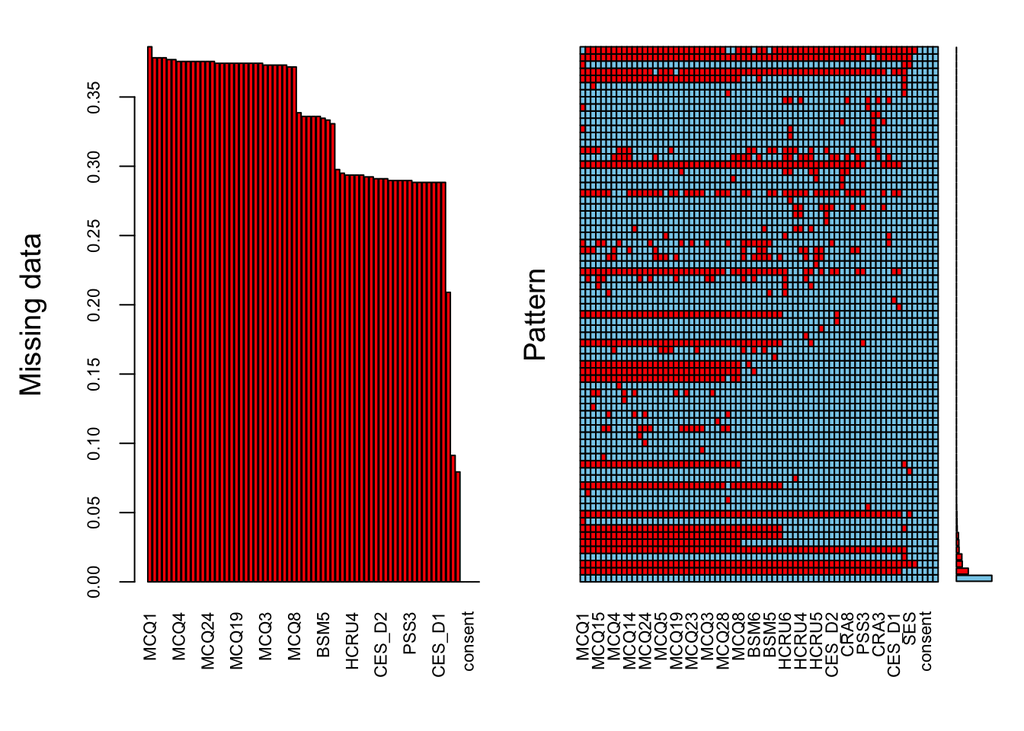

```
##
##  Variables sorted by number of missings:
##  Variable      Count
##      MCQ1 0.38624339
##     MCQ12 0.37830688
##     MCQ13 0.37830688
##     MCQ15 0.37830688
##     MCQ29 0.37698413
##     MCQ30 0.37698413
##      MCQ4 0.37566138
##      MCQ9 0.37566138
##     MCQ11 0.37566138
##     MCQ14 0.37566138
##     MCQ17 0.37566138
##     MCQ22 0.37566138
##     MCQ24 0.37566138
##     MCQ25 0.37566138
##      MCQ2 0.37433862
##      MCQ5 0.37433862
##      MCQ7 0.37433862
##     MCQ16 0.37433862
##     MCQ19 0.37433862
##     MCQ20 0.37433862
##     MCQ21 0.37433862
##     MCQ23 0.37433862
##     MCQ26 0.37433862
##     MCQ27 0.37433862
##      MCQ3 0.37301587
##     MCQ10 0.37301587
##     MCQ18 0.37301587
##     MCQ28 0.37301587
##       Edu 0.37301587
##      MCQ6 0.37169312
##      MCQ8 0.37169312
##      BSM2 0.33862434
##      BSM4 0.33597884
##      BSM6 0.33597884
##      BSM7 0.33597884
##      BSM8 0.33597884
##      BSM5 0.33465608
```

[output cut: 17 more lines]

```
##      PSS3 0.28968254
##      CRA1 0.28835979
##      CRA2 0.28835979
##      CRA3 0.28835979
##      CRA6 0.28835979
##     HCRU2 0.28835979
##    CES_D1 0.28835979
##    CES_D3 0.28835979
##       Age 0.20899471
##       SES 0.09126984
##    gender 0.07936508
##        id 0.00000000
##   consent 0.00000000
##  Platform 0.00000000
##  duration 0.00000000
```

```r
# visualise missing data
library(VIM)
mice_plot <- aggr(raw_data,numbers=TRUE, sortVars=TRUE,
                    labels=names(raw_data), cex.axis=.7,
                    gap=3, ylab=c("Missing data","Pattern"))
```

```r
# Percentage of missing data per row
no_missing <- raw_data
percent_missing <- function(x){sum(is.na(x)/length(x)*100)}

missing <- apply(no_missing,1,percent_missing)
table(missing)
```

```
## missing
##                0 1.44927536231884 2.89855072463768 4.34782608695652
##              357               91                5                8
## 5.79710144927536  7.2463768115942 10.1449275362319 11.5942028985507
##                1                1                3                2
## 17.3913043478261 21.7391304347826 24.6376811594203  27.536231884058
##                2                2                1                1
## 30.4347826086957 43.4782608695652 44.9275362318841 46.3768115942029
##                1                1               25                4
## 47.8260869565217 55.0724637681159 56.5217391304348 57.9710144927536
##                1                2               21                9
## 59.4202898550725 62.3188405797101 69.5652173913043 85.5072463768116
##                1                1                1                1
## 86.9565217391304 89.8550724637681  91.304347826087 94.2028985507246
##                2              121               32               59
```

```r
# Look for data to be imputed based on rows
replace_rows <- subset(no_missing, missing <= 5)
no_rows <- subset(no_missing, missing > 5)
```

```r
# Then look for data to be imputed based on columns
missing <- apply(replace_rows, 2, percent_missing)
table(missing)
```

```
## missing
##                 0 0.216919739696312 0.433839479392625 0.650759219088937
##                32                23                 4                 6
## 0.867678958785249  1.08459869848156  1.95227765726681  12.5813449023861
##                 1                 1                 1                 1
```

```r
replace_columns <- replace_rows %>% select_if(missing<=5)
no_columns <- replace_rows %>% select_if(missing > 5)
```

**IMPUTE DATA** - Mice easily imputes, taking into account data type.

```r
tempnomiss <- mice(replace_columns)
```

# Visualise missing data AGAIN!!!

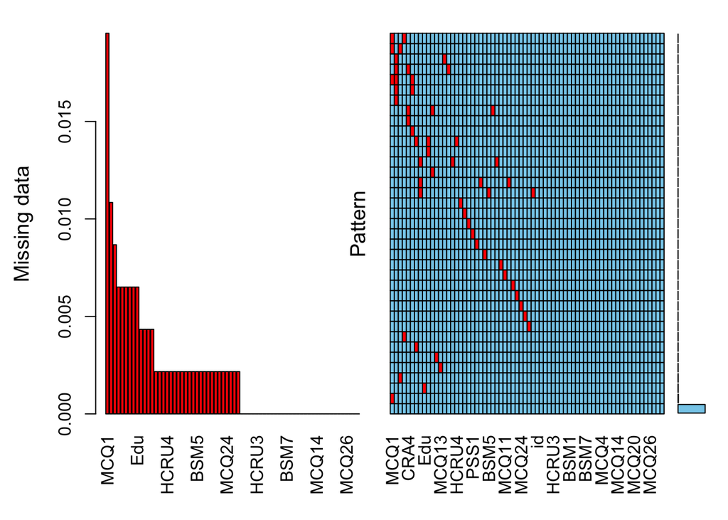

```
##
##  Variables sorted by number of missings:
##  Variable       Count
##      MCQ1 0.019522777
##      CRA2 0.010845987
##      CRA1 0.008676790
##       SES 0.006507592
##      CRA4 0.006507592
##      CRA5 0.006507592
##     HCRU1 0.006507592
##     HCRU6 0.006507592
##       Edu 0.006507592
##      CRA7 0.004338395
##     HCRU5 0.004338395
##     MCQ12 0.004338395
##     MCQ13 0.004338395
##      CRA3 0.002169197
##      CRA6 0.002169197
##     HCRU2 0.002169197
##     HCRU4 0.002169197
##    CES_D1 0.002169197
##    CES_D3 0.002169197
##    CES_D4 0.002169197
##      PSS1 0.002169197
##      PSS2 0.002169197
##      PSS4 0.002169197
##      BSM3 0.002169197
##      BSM5 0.002169197
##      MCQ6 0.002169197
##      MCQ7 0.002169197
##      MCQ9 0.002169197
##     MCQ11 0.002169197
##     MCQ15 0.002169197
##     MCQ18 0.002169197
##     MCQ22 0.002169197
##     MCQ24 0.002169197
##     MCQ27 0.002169197
##     MCQ29 0.002169197
##     MCQ30 0.002169197
##        id 0.000000000
```

[output cut: 16 more lines]

```
##      MCQ5 0.000000000
##      MCQ8 0.000000000
##     MCQ10 0.000000000
##     MCQ14 0.000000000
##     MCQ16 0.000000000
##     MCQ17 0.000000000
##     MCQ19 0.000000000
##     MCQ20 0.000000000
##     MCQ21 0.000000000
##     MCQ23 0.000000000
##     MCQ25 0.000000000
##     MCQ26 0.000000000
##     MCQ28 0.000000000
##  Platform 0.000000000
##  duration 0.000000000
```

```r
library(VIM)
mice_plot <- aggr(replace_columns,numbers=TRUE, sortVars=TRUE,
                  labels=names(replace_columns), cex.axis=1,
                  gap=1, ylab=c("Missing data","Pattern"))
```

```r
# Get all the imputed data
imputed_columns <- complete(tempnomiss)
```

```r
# Putting the data we dropped before back together with the rest
all_columns <- cbind(no_columns, imputed_columns)
'all_rows <- rbind(all_columns, no_rows)' # Only use if you want all other rows with NA binded as well
```

```
## [1] "all_rows <- rbind(all_columns, no_rows)"
```

# Outliers

```r
# Prepare for outlier detection
columns = c("id", "Platform", "consent","duration", "Age","gender", "Edu")
demographics <- subset(all_columns, select = columns)
all_columns <- all_columns[ , ! names(all_columns) %in% columns]
imputed_data <- cbind(demographics, all_columns) # Save all clean data
```

**Outliers Mahalanobis** - Degrees of freedom in this case is based on the nr of variables (columns) - Detect outliers based on **unscored** data

```r
# Mahalanobis for unscored data
mahal <- mahalanobis(imputed_data[ , -c(1:7)],
  colMeans(imputed_data[ , -c(1:7)], na.rm=TRUE),
  cov(imputed_data[ , -c(1:7)], use ="pairwise.complete.obs"))

cutoff <- qchisq(p = 1 - .001, #1 minus alpha
                 df = ncol(imputed_data[ , -c(1:7)])) # number of columns
```

```r
# Drop all outliers detected based on *unscored* data
cutoff
```

```
## [1] 102.1662
```

```r
summary(mahal < cutoff) #notice the direction
```

```
##    Mode   FALSE    TRUE
## logical      30     431
```

```r
no_outlier <- subset(imputed_data, mahal < cutoff)

summary(no_outlier)
```

```
##       id               Platform         consent     duration
##  Length:431         Min.   :0.0000   Min.   :1   Min.   :    68.0
##  Class :character   1st Qu.:1.0000   1st Qu.:1   1st Qu.:   584.5
##  Mode  :character   Median :1.0000   Median :1   Median :   805.0
##                     Mean   :0.7819   Mean   :1   Mean   :  3931.7
##                     3rd Qu.:1.0000   3rd Qu.:1   3rd Qu.:  1147.5
##                     Max.   :1.0000   Max.   :1   Max.   :347791.0
##
##       Age            gender           Edu             SES
##  Min.   :18.00   Min.   :1.000   Min.   :1.000   Min.   : 1.000
##  1st Qu.:24.00   1st Qu.:1.000   1st Qu.:2.000   1st Qu.: 5.000
##  Median :33.00   Median :2.000   Median :3.000   Median : 8.000
##  Mean   :35.22   Mean   :1.682   Mean   :3.051   Mean   : 7.654
##  3rd Qu.:46.00   3rd Qu.:2.000   3rd Qu.:4.000   3rd Qu.:10.000
##  Max.   :69.00   Max.   :4.000   Max.   :5.000   Max.   :12.000
##  NA's   :57
##       CRA1            CRA2            CRA3            CRA4
##  Min.   :1.000   Min.   :1.000   Min.   :1.000   Min.   :1.000
##  1st Qu.:4.000   1st Qu.:3.000   1st Qu.:3.000   1st Qu.:3.000
##  Median :5.000   Median :5.000   Median :4.000   Median :5.000
##  Mean   :5.053   Mean   :4.545   Mean   :4.155   Mean   :4.664
##  3rd Qu.:7.000   3rd Qu.:6.000   3rd Qu.:5.500   3rd Qu.:6.000
##  Max.   :7.000   Max.   :7.000   Max.   :7.000   Max.   :7.000
##
##       CRA5            CRA6            CRA7            CRA8
##  Min.   :1.000   Min.   :1.000   Min.   :1.000   Min.   :1.000
##  1st Qu.:4.000   1st Qu.:4.000   1st Qu.:4.000   1st Qu.:4.000
##  Median :5.000   Median :5.000   Median :5.000   Median :5.000
##  Mean   :5.227   Mean   :4.705   Mean   :4.791   Mean   :5.028
##  3rd Qu.:7.000   3rd Qu.:6.000   3rd Qu.:6.000   3rd Qu.:6.000
##  Max.   :7.000   Max.   :7.000   Max.   :7.000   Max.   :7.000
##
##      HCRU1           HCRU2           HCRU3           HCRU4
##  Min.   :1.000   Min.   :1.000   Min.   :1.000   Min.   :1.000
##  1st Qu.:4.000   1st Qu.:3.000   1st Qu.:3.000   1st Qu.:4.000
##  Median :5.000   Median :5.000   Median :5.000   Median :5.000
##  Mean   :5.077   Mean   :4.592   Mean   :4.629   Mean   :4.817
##  3rd Qu.:6.000   3rd Qu.:6.000   3rd Qu.:6.000   3rd Qu.:6.000
##  Max.   :7.000   Max.   :7.000   Max.   :7.000   Max.   :7.000
##
```

[output cut: 81 more lines]

```
##  Min.   :1.000   Min.   :1.000   Min.   :1.000   Min.   :1.000
##  1st Qu.:1.000   1st Qu.:2.000   1st Qu.:1.000   1st Qu.:2.000
##  Median :2.000   Median :3.000   Median :2.000   Median :3.000
##  Mean   :1.875   Mean   :2.814   Mean   :1.819   Mean   :2.733
##  3rd Qu.:3.000   3rd Qu.:4.000   3rd Qu.:2.000   3rd Qu.:3.000
##  Max.   :4.000   Max.   :4.000   Max.   :4.000   Max.   :4.000
##
##      MCQ28           MCQ29           MCQ30
##  Min.   :1.000   Min.   :1.000   Min.   :1.000
##  1st Qu.:1.000   1st Qu.:1.000   1st Qu.:2.000
##  Median :1.000   Median :1.000   Median :2.000
##  Mean   :1.726   Mean   :1.768   Mean   :2.487
##  3rd Qu.:2.000   3rd Qu.:2.000   3rd Qu.:3.000
##  Max.   :4.000   Max.   :4.000   Max.   :4.000
##
```

# Score data

- Prepare to score the data with temporarily no outliers

```r
# Create MCQ subscale variable groups
mcq_pos <- c("MCQ1","MCQ7","MCQ10",
             "MCQ19","MCQ23","MCQ28")

mcq_neg <- c("MCQ2","MCQ4","MCQ9",
             "MCQ11","MCQ15","MCQ21")

mcq_cc <- c("MCQ8","MCQ14","MCQ17",
            "MCQ24","MCQ26","MCQ29")

mcq_nc <- c("MCQ6","MCQ13","MCQ20",
            "MCQ22","MCQ25","MCQ27")

mcq_csc <- c("MCQ3","MCQ5","MCQ12",
             "MCQ16","MCQ18","MCQ30")
```

```r
# Function to Score data
function_score_data <-function(no_outlier){

#save variables in separate data frame
scored_data <- no_outlier %>%

  #row mean of the selected columns
  mutate(across(c("PSS2", "PSS3"), ~{6 - .}), # recode PSS items 2 & 3 (6 - response)
         across(c("BSM1", "BSM3", "BSM7", "BSM8"), ~{8 - .}), # first recode BSM items 1, 3, 7, 8 (8 - response)
         mean_cra = rowMeans(select(., starts_with("CRA"))),
         mean_hcru = rowMeans(select(., starts_with("HCRU"))),
         mean_pss = rowMeans(select(., starts_with("PSS"))),

         mean_bsm = rowMeans(select(., starts_with("BSM"))),
         #for cesd, we need the sum
         sum_cesd = rowSums(select(., starts_with("CES_D"))),

         # sum all MCQ subscales
         sum_pos = rowSums(select(.,all_of(mcq_pos))),
         sum_neg = rowSums(select(.,all_of(mcq_neg))),
         sum_cc = rowSums(select(.,all_of(mcq_cc))),
         sum_nc = rowSums(select(.,all_of(mcq_nc))),
         sum_csc = rowSums(select(.,all_of(mcq_csc))),
         sum_MCQ = rowSums(select(.,starts_with("MCQ"))))%>%
return(scored_data)
}
```

```r
# Score the data with no outliers
scored_data <- function_score_data(no_outlier) #score data first, to find outliers among scored data
```

# Summary of cleaned data

```r
# Missing Data & outliers checked
summary(scored_data)
```

```
##       id               Platform         consent     duration
##  Length:431         Min.   :0.0000   Min.   :1   Min.   :    68.0
##  Class :character   1st Qu.:1.0000   1st Qu.:1   1st Qu.:   584.5
##  Mode  :character   Median :1.0000   Median :1   Median :   805.0
##                     Mean   :0.7819   Mean   :1   Mean   :  3931.7
##                     3rd Qu.:1.0000   3rd Qu.:1   3rd Qu.:  1147.5
##                     Max.   :1.0000   Max.   :1   Max.   :347791.0
##
##       Age            gender           Edu             SES
##  Min.   :18.00   Min.   :1.000   Min.   :1.000   Min.   : 1.000
##  1st Qu.:24.00   1st Qu.:1.000   1st Qu.:2.000   1st Qu.: 5.000
##  Median :33.00   Median :2.000   Median :3.000   Median : 8.000
##  Mean   :35.22   Mean   :1.682   Mean   :3.051   Mean   : 7.654
##  3rd Qu.:46.00   3rd Qu.:2.000   3rd Qu.:4.000   3rd Qu.:10.000
##  Max.   :69.00   Max.   :4.000   Max.   :5.000   Max.   :12.000
##  NA's   :57
##       CRA1            CRA2            CRA3            CRA4
##  Min.   :1.000   Min.   :1.000   Min.   :1.000   Min.   :1.000
##  1st Qu.:4.000   1st Qu.:3.000   1st Qu.:3.000   1st Qu.:3.000
##  Median :5.000   Median :5.000   Median :4.000   Median :5.000
##  Mean   :5.053   Mean   :4.545   Mean   :4.155   Mean   :4.664
##  3rd Qu.:7.000   3rd Qu.:6.000   3rd Qu.:5.500   3rd Qu.:6.000
##  Max.   :7.000   Max.   :7.000   Max.   :7.000   Max.   :7.000
##
##       CRA5            CRA6            CRA7            CRA8
##  Min.   :1.000   Min.   :1.000   Min.   :1.000   Min.   :1.000
##  1st Qu.:4.000   1st Qu.:4.000   1st Qu.:4.000   1st Qu.:4.000
##  Median :5.000   Median :5.000   Median :5.000   Median :5.000
##  Mean   :5.227   Mean   :4.705   Mean   :4.791   Mean   :5.028
##  3rd Qu.:7.000   3rd Qu.:6.000   3rd Qu.:6.000   3rd Qu.:6.000
##  Max.   :7.000   Max.   :7.000   Max.   :7.000   Max.   :7.000
##
##      HCRU1           HCRU2           HCRU3           HCRU4
##  Min.   :1.000   Min.   :1.000   Min.   :1.000   Min.   :1.000
##  1st Qu.:4.000   1st Qu.:3.000   1st Qu.:3.000   1st Qu.:4.000
##  Median :5.000   Median :5.000   Median :5.000   Median :5.000
##  Mean   :5.077   Mean   :4.592   Mean   :4.629   Mean   :4.817
##  3rd Qu.:6.000   3rd Qu.:6.000   3rd Qu.:6.000   3rd Qu.:6.000
##  Max.   :7.000   Max.   :7.000   Max.   :7.000   Max.   :7.000
##
```

[output cut: 105 more lines]

```
##  Min.   : 6.00   Min.   : 6.00   Min.   : 6.0   Min.   : 6.00   Min.   : 6.00
##  1st Qu.: 7.50   1st Qu.:10.00   1st Qu.: 8.0   1st Qu.:12.00   1st Qu.:13.50
##  Median :10.00   Median :13.00   Median :11.0   Median :15.00   Median :16.00
##  Mean   :10.83   Mean   :13.85   Mean   :11.9   Mean   :14.49   Mean   :16.06
##  3rd Qu.:13.00   3rd Qu.:17.00   3rd Qu.:14.5   3rd Qu.:17.00   3rd Qu.:19.00
##  Max.   :23.00   Max.   :24.00   Max.   :24.0   Max.   :24.00   Max.   :24.00
##
##     sum_MCQ
##  Min.   : 33.00
##  1st Qu.: 58.00
##  Median : 66.00
##  Mean   : 67.13
##  3rd Qu.: 76.50
##  Max.   :110.00
##
```

# Assumptions

- Additivity is the assumption that each variable adds something to the model
- You basically do not want to use the same variable twice, as that lowers power
- Often this is described as multicollinearity (The problem is multicollineartiy). The assumption is called additivity.
- Mainly, SEM analysis has a lot of correlated variables, you just want to make sure they aren’t perfectly correlated

# Additivity

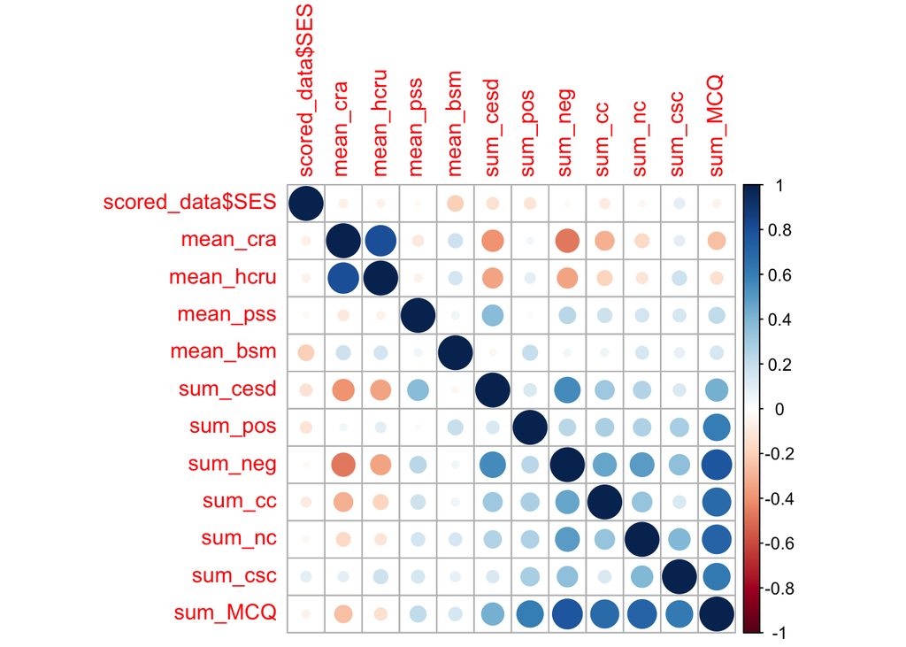

```r
library(corrplot)
plot_data <- cbind(scored_data$SES,scored_data[ , -c(1:69)])
corrplot(cor(plot_data))
```

# Assumptions Set Up

```r
random_variable <- rchisq(nrow(scored_data), 7)
fake_model <- lm(random_variable ~ ., # What's the difference if I regress on scored_data$sum_cesd ??
                 data = scored_data[ , -c(1:69)])
standardized <- rstudent(fake_model) # residuals
fitvalues <- scale(fake_model$fitted.values) # z-score them
```

# Linearity

- We assume the the multivariate relationship between continuous variables is linear (i.e., no curved)
- There are many ways to test this, but we can use a QQ/PP Plot to examine for linearity

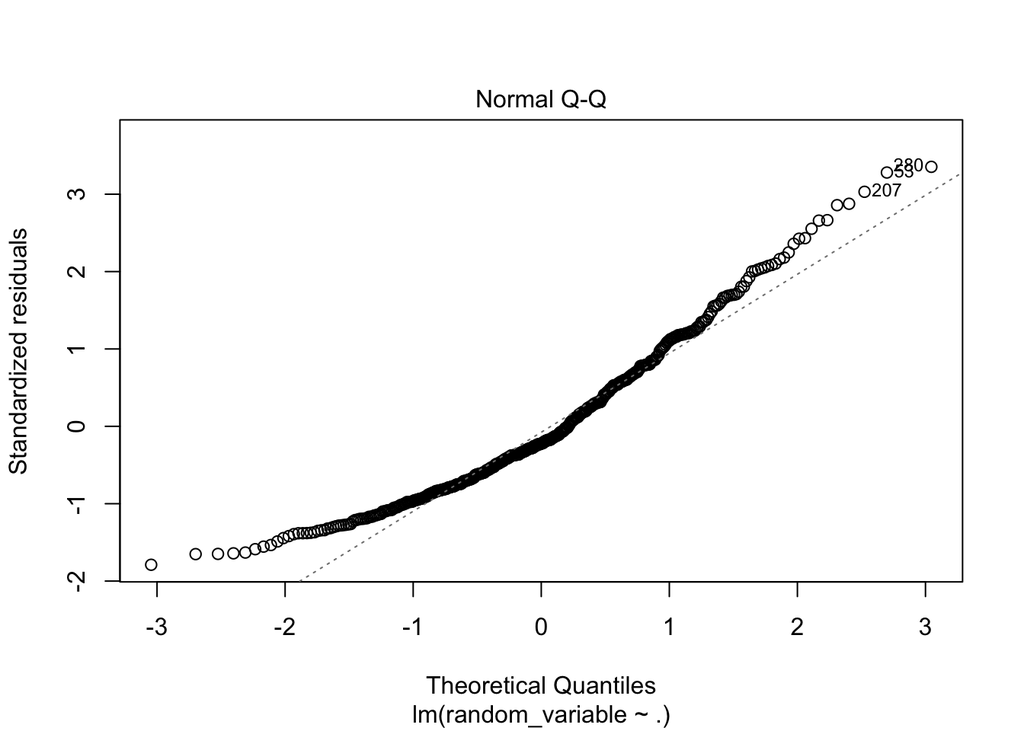

```r
plot(fake_model, 2)
```

# Normality - We expect that the residuals are normally distributed

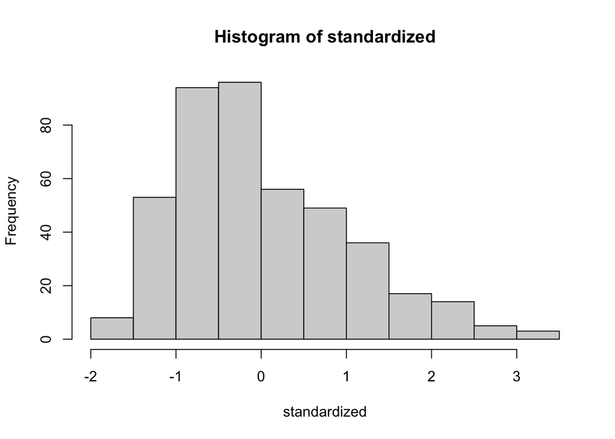

```r
hist(standardized)
```

# Assumptions Homogeneity + Homoscedasticity - These assumptions are about equality of the variances - Here the assumption is equality in the spread of variance across predicted values

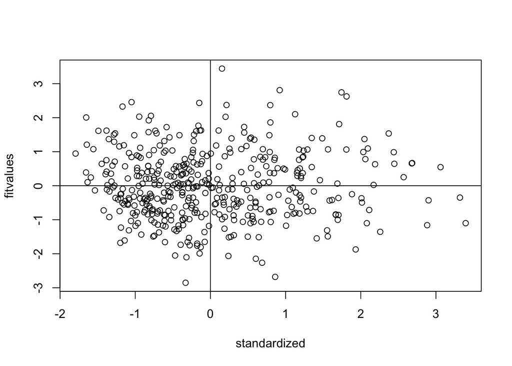

```r
{plot(standardized, fitvalues)
  abline(v = 0)
  abline(h = 0)
}
```

```r
# Check for duplicates
sum(duplicated(scored_data))
```

```
## [1] 0
```

```r
# Check demographics
scored_data$gender <- factor(scored_data$gender, levels=c(1,2,3,4)) # Factor gender
summary(scored_data$gender)
```

```
##   1   2   3   4
## 142 286   1   2
```

# Descriptives

- In the first step, the data are summarized to get the descriptive statistics.
- Subsequently, the data are reformatted.

```r
descriptives <- scored_data %>%
  dplyr::summarize(across(c(SES, Age, mean_cra, mean_hcru,sum_cesd,
                            mean_pss, mean_bsm, sum_pos,
                            sum_neg, sum_cc, sum_nc, sum_csc, sum_MCQ),
                          list(mean = mean, sd = sd, min = min, max = max))) %>%

  # bring everything in long format
  pivot_longer(everything(), names_to = "name") %>%

  # separate names at last underscore
  separate(name, into = c("name","descriptive"), sep = "_(?=[^_]+$)") %>%

  # get into a bit wider format again
  pivot_wider(names_from = name, values_from = value) %>%

  # rename to have nicer column names
  rename(Summary = descriptive,
         CRA = mean_cra,  #
         HCRU = mean_hcru, #
         PSS = mean_pss,  #
         CESD = sum_cesd, #
         BSM = mean_bsm,  #
         POS = sum_pos,  #
         NEG = sum_neg, #
         CC = sum_cc, #
         NC = sum_nc, #
         CSC = sum_csc, #
         MCQT = sum_MCQ) # MCQ =Meta Cognitions Questionnaire Total
```

# Cronbach’s alphas

- Select the items from the *raw* or *un-scored* data that belong to the specific scale.
- calculate alpha and extract raw_alpha from the list the alpha function generates.

```r
# Calculate cronbach’s alphas
alpha <- scored_data %>%
  dplyr::summarize(
    # Replication Block Alphas
    cra_alpha = select(.,starts_with("CRA")) %>% psych::alpha() %>%
      pluck("total", "raw_alpha"), # extract total and then raw_alpha from list
    hcru_alpha = select(.,starts_with("HCRU")) %>% psych::alpha() %>%
      pluck("total", "raw_alpha"),
    cesd_alpha = select(.,starts_with("CES_D")) %>% psych::alpha() %>%
      pluck("total", "raw_alpha"),
    pss_alpha = select(.,starts_with("PSS")) %>% psych::alpha(check.keys=TRUE) %>%
      pluck("total", "raw_alpha"),

    # BSM Alphas
    BSM_alpha = select(.,starts_with("BSM")) %>% psych::alpha(check.keys=TRUE) %>%
      pluck("total", "raw_alpha"),

    # MCQ scale Alphas
    pos_alpha = select(.,all_of(mcq_pos)) %>% psych::alpha() %>%
      pluck("total", "raw_alpha"),
    neg_alpha = select(.,all_of(mcq_neg)) %>% psych::alpha() %>%
      pluck("total", "raw_alpha"),
    cc_alpha = select(.,all_of(mcq_cc)) %>% psych::alpha() %>%
      pluck("total", "raw_alpha"),
    nc_alpha = select(.,all_of(mcq_nc)) %>% psych::alpha() %>%
      pluck("total", "raw_alpha"),
    csc_alpha = select(.,all_of(mcq_csc)) %>% psych::alpha() %>%
      pluck("total", "raw_alpha"),
    mcq_alpha = select(.,all_of(mcq_csc)) %>% psych::alpha() %>%
      pluck("total", "raw_alpha"))
```

```r
# add alphas as extra row to the descriptives table
descriptives <- descriptives %>%
  add_row(Summary = "alpha", SES = NA, CRA = alpha$cra_alpha, HCRU = alpha$hcru_alpha,
          PSS = alpha$pss_alpha, CESD = alpha$cesd_alpha, BSM = alpha$BSM_alpha,
          POS = alpha$pos_alpha, NEG = alpha$neg_alpha, CC = alpha$cc_alpha,
          NC = alpha$nc_alpha, CSC = alpha$csc_alpha, MCQT = alpha$mcq_alpha)
```

# Descriptives table

```r
# Make a nicely formatted table
library(rmarkdown)
apa_table(descriptives) # is only shown when RMarkdown document is knitted
```

(#tab:unnamed-chunk-29)

[output not shown]

# Plot monthly family income

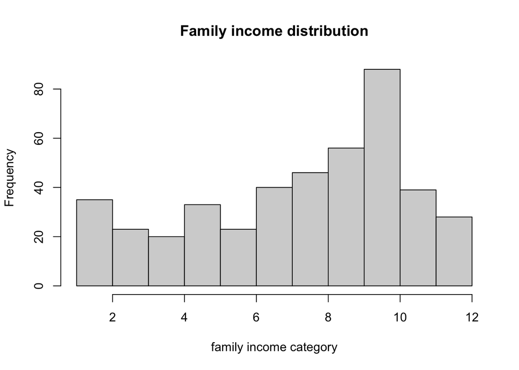

```r
income_plot<-hist(scored_data$SES,
                  main="Family income distribution",
                  xlab="family income category")
```

# Mean centre all IVs

```r
# Mean centre all IVs for regressions with interaction terms
centre_data_to_csv <- function(scored_data){
  centred_data <- scored_data %>%
  mutate(CRA_c = scale(mean_cra, center = TRUE, scale = FALSE),
         SES_c = scale(SES, center = TRUE, scale = FALSE),
         PSS_c = scale(mean_pss, center = TRUE, scale = FALSE),
         HCRU_c = scale(mean_hcru, center = TRUE, scale = FALSE),
         BSM_c = scale(mean_bsm, center = TRUE, scale = FALSE),
         POS_c = scale(sum_pos, center = TRUE, scale = FALSE),
         NEG_c = scale(sum_neg, center = TRUE, scale = FALSE),
         CC_c = scale(sum_cc, center = TRUE, scale = FALSE),
         NC_c = scale(sum_nc, center = TRUE, scale = FALSE),
         CSC_c = scale(sum_csc, center = TRUE, scale = FALSE),
         MCQ_c = scale(sum_MCQ, center = TRUE, scale = FALSE))%>%

  # select the scores/final variables used, remove the raw items
  select(Age, gender, Edu, sum_cesd, SES_c , CRA_c, PSS_c, HCRU_c, BSM_c, POS_c, NEG_c, CC_c, CSC_c, MCQ_c)
# Save prepared data
write.csv(centred_data,"ready_for_analysis.csv", row.names = FALSE)

return(centred_data)
}
```

# read prepared data for analysis

```r
# data <- read_csv("ready_for_analysis.csv") # Read csv data from computer
# or
ready_for_analysis <- centre_data_to_csv(scored_data)
```

# Hypotheses B1 & B2: Three-way interaction

```r
# Rename variables for convenience in modelling
data <- ready_for_analysis %>% mutate(rename(ready_for_analysis,
                                "X" = "CRA_c",
                                "Y" = "sum_cesd",
                                "W" = "SES_c",
                                "Z" = "BSM_c",
                                "COV" = "PSS_c",
                               "M" = "NEG_c"))
```

Create interaction terms

```r
# Create interaction terms
data <- data %>% mutate(X.W = X * W,
                        X.Z = X * Z,
                        W.Z = W * Z,
                        X.W.Z = X * W * Z,
                        M.W = M * W,
                        M.Z = M * Z,
                        M.W.Z = M * W * Z)
```

# Three-way moderation model

```r
mod.mod.model = lm(Y ~ COV + X + W + Z + X*W  + X*Z + W*Z + X*W*Z, data = data)
summary(mod.mod.model)
```

```
##
## Call:
## lm(formula = Y ~ COV + X + W + Z + X * W + X * Z + W * Z + X *
##     W * Z, data = data)
##
## Residuals:
##     Min      1Q  Median      3Q     Max
## -8.4666 -2.3324 -0.4082  1.7770  9.7306
##
## Coefficients:
##             Estimate Std. Error t value Pr(>|t|)
## (Intercept)  5.33880    0.16636  32.092  < 2e-16 ***
## COV          2.76525    0.34269   8.069 7.43e-15 ***
## X           -1.10188    0.13669  -8.061 7.86e-15 ***
## W           -0.20037    0.05498  -3.644 0.000301 ***
## Z           -0.11595    0.30050  -0.386 0.699794
## X:W          0.05473    0.04210   1.300 0.194294
## X:Z          0.19911    0.24763   0.804 0.421807
## W:Z         -0.05053    0.08957  -0.564 0.572903
## X:W:Z        0.14822    0.07282   2.035 0.042437 *
## ---
## Signif. codes:  0 '***' 0.001 '**' 0.01 '*' 0.05 '.' 0.1 ' ' 1
##
## Residual standard error: 3.346 on 422 degrees of freedom
## Multiple R-squared:  0.2982, Adjusted R-squared:  0.2849
## F-statistic: 22.42 on 8 and 422 DF,  p-value: < 2.2e-16
```

# Check model fit

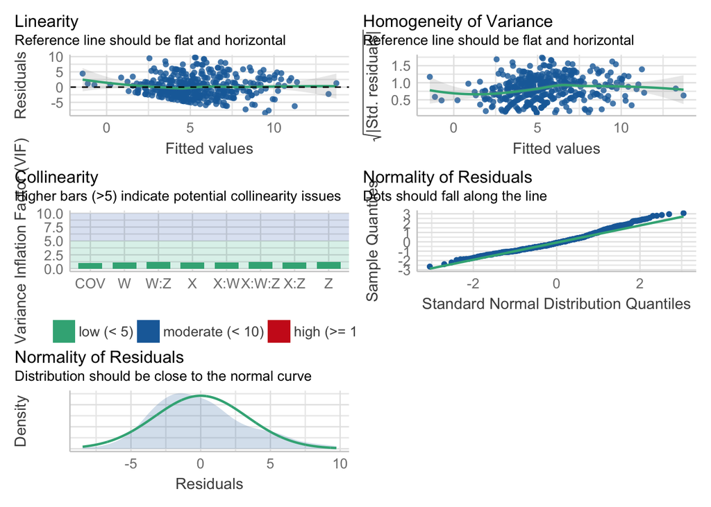

```r
performance::check_model(mod.mod.model)
```

# Simple slopes analysis

```r
interactions::sim_slopes(mod.mod.model, pred = X, modx=W, mod2 = Z, modxvals = NULL, jnalpha = 0.05, digits = 3, n.sd = 1)
```

```
## ███████████████ While Z (2nd moderator) = -5.862329e-01 (- 1 SD) ███████████████
##
## JOHNSON-NEYMAN INTERVAL
##
## When W is INSIDE the interval [-7.573, 13.145], the slope of X is p < .05.
##
## Note: The range of observed values of W is [-6.654, 4.346]
##
## SIMPLE SLOPES ANALYSIS
##
## Slope of X when W = -3.049777e+00 (- 1 SD):
##
##     Est.    S.E.   t val.       p
## -------- ------- -------- -------
##   -1.121   0.264   -4.243   0.000
##
## Slope of X when W = -2.225598e-16 (Mean):
##
##     Est.    S.E.   t val.       p
## -------- ------- -------- -------
##   -1.219   0.194   -6.294   0.000
##
## Slope of X when W =  3.049777e+00 (+ 1 SD):
##
##     Est.    S.E.   t val.       p
## -------- ------- -------- -------
##   -1.317   0.274   -4.807   0.000
##
## ████████████████ While Z (2nd moderator) =  1.298265e-16 (Mean) ████████████████
##
## JOHNSON-NEYMAN INTERVAL
##
## When W is INSIDE the interval [-40.254, 7.364], the slope of X is p < .05.
##
## Note: The range of observed values of W is [-6.654, 4.346]
##
## SIMPLE SLOPES ANALYSIS
##
## Slope of X when W = -3.049777e+00 (- 1 SD):
##
```

[output cut: 28 more lines]

```
##     Est.    S.E.   t val.       p
## -------- ------- -------- -------
##   -1.417   0.218   -6.514   0.000
##
## Slope of X when W = -2.225598e-16 (Mean):
##
##     Est.    S.E.   t val.       p
## -------- ------- -------- -------
##   -0.985   0.205   -4.806   0.000
##
## Slope of X when W =  3.049777e+00 (+ 1 SD):
##
##     Est.    S.E.   t val.       p
## -------- ------- -------- -------
##   -0.553   0.317   -1.744   0.082
```

# Plot simple slopes for interaction

[figure not shown]

```r
interactions::interact_plot(mod.mod.model, pred = X, modx = W, mod2 = Z, centered = "none", y.label = "Cognitive Reappraisal Ability",x.label = "Socioeconomic Status", interval = TRUE, data = data)
```

# Hypotheses C1 & C2: Moderated Mediation

```r
# The Model
MOD.MED.model <-
"
# Mediator
M ~ a*X

# Outcome being predicted by the model
Y ~ c1*X + c2*W + c3*Z + c4*X.W + c5*X.Z + c6*W.Z + c7*X.W.Z +
b1*M + b2*W + b3*Z + b4*M.W + b5*M.Z + b6*W.Z + b7*M.W.Z + g*COV

# Covariance: A main predictor's covariance is fixed so it does not
# covary with the rest of the variables, since the theory does not explicitely address this
COV ~~ COV

# Intercept and variance of W for conditional effects analysis
W ~ W.mean*1
W ~~ W.var * W

# Intercept and variance of Z for conditional effects analysis
Z ~ Z.mean*1
Z ~~ Z.var*Z

# Indirect effect of X on Y through M, conditional on mean values of W and Z
indirect := (a) * ( b1 + b4*W.mean + b5*Z.mean)

# Direct effect of X on Y, moderated by W and Z
direct := c1 + c4*W.mean + c5*Z.mean

# Total effect
total := direct + indirect

# Proportion of effect mediated
prop.mediated := indirect / total

# Conditional indirect effect through mediator (M)
indirect.below :=(a)*(b1+b4*(W.mean - sqrt(W.var))+ b5*(Z.mean - sqrt(Z.var)))
indirect.above :=(a)*(b1+b4*(W.mean + sqrt(W.var))+ b5*(Z.mean + sqrt(Z.var)))

# Conditional direct effect moderated by W and Z
direct.below:=c1 + c4*(W.mean - sqrt(W.var)) + c5*(Z.mean - sqrt(Z.var))
direct.above:=c1 + c4*(W.mean + sqrt(W.var)) + c5*(Z.mean + sqrt(Z.var))

# Conditional total effect
total.below := direct.below + indirect.below
total.above := direct.above + indirect.above

# Proportion of mediation under conditions of W and one SD above or below mean
prop.mediated.below := indirect.below / total.below
prop.mediated.above := indirect.above / total.above
"
```

```r
# Fit the model
Mod.Med.SEM <- sem(model = MOD.MED.model,
                   data = data,
                   se = "bootstrap",
                   bootstrap = 200) # do 5000 when actually running the code
# Model summary
summary(Mod.Med.SEM, fit.measures = FALSE, standardize = TRUE, rsquare = TRUE)
```

```
## lavaan 0.6-10 ended normally after 19 iterations
##
##   Estimator                                         ML
##   Optimization method                           NLMINB
##   Number of model parameters                        23
##
##   Number of observations                           431
##
## Model Test User Model:
##
##   Test statistic                               180.359
##   Degrees of freedom                                37
##   P-value (Chi-square)                           0.000
##
## Parameter Estimates:
##
##   Standard errors                            Bootstrap
##   Number of requested bootstrap draws              200
##   Number of successful bootstrap draws             200
##
## Regressions:
##                    Estimate  Std.Err  z-value  P(>|z|)   Std.lv  Std.all
##   M ~
##     X          (a)   -1.686    0.171   -9.858    0.000   -1.686   -0.466
##   Y ~
##     X         (c1)   -0.420    0.157   -2.668    0.008   -0.420   -0.134
##     W         (c2)   -0.186    0.059   -3.142    0.002   -0.186   -0.146
##     Z         (c3)   -0.446    0.283   -1.579    0.114   -0.446   -0.067
##     X.W       (c4)    0.128    0.054    2.342    0.019    0.128    0.131
##     X.Z       (c5)    0.234    0.275    0.851    0.395    0.234    0.042
##     W.Z       (c6)   -0.043    0.083   -0.521    0.602   -0.043   -0.022
##     X.W.Z     (c7)    0.113    0.085    1.326    0.185    0.113    0.071
##     M         (b1)    0.387    0.046    8.334    0.000    0.387    0.446
##     M.W       (b4)    0.011    0.016    0.720    0.471    0.011    0.039
##     M.Z       (b5)    0.000    0.079    0.006    0.995    0.000    0.000
##     M.W.Z     (b7)    0.005    0.022    0.244    0.808    0.005    0.013
##     COV        (g)    2.186    0.346    6.325    0.000    2.186    0.268
##
## Intercepts:
##                    Estimate  Std.Err  z-value  P(>|z|)   Std.lv  Std.all
```

[output cut: 18 more lines]

```
##
## Defined Parameters:
##                    Estimate  Std.Err  z-value  P(>|z|)   Std.lv  Std.all
##     indirect         -0.653    0.101   -6.460    0.000   -0.653   -0.208
##     direct           -0.420    0.157   -2.666    0.008   -0.420   -0.134
##     total            -1.073    0.143   -7.518    0.000   -1.073   -0.342
##     prop.mediated     0.609    0.117    5.192    0.000    0.609    0.609
##     indirect.below   -0.595    0.151   -3.949    0.000   -0.595   -0.190
##     indirect.above   -0.711    0.163   -4.372    0.000   -0.711   -0.227
##     direct.below     -0.945    0.277   -3.414    0.001   -0.945   -0.307
##     direct.above      0.106    0.301    0.352    0.725    0.106    0.040
##     total.below      -1.541    0.233   -6.616    0.000   -1.541   -0.497
##     total.above      -0.605    0.264   -2.289    0.022   -0.605   -0.187
##     prop.medtd.blw    0.386    0.111    3.471    0.001    0.386    0.382
##     prop.meditd.bv    1.175    1.743    0.674    0.500    1.175    1.211
```

# Plot the moderated mediation model

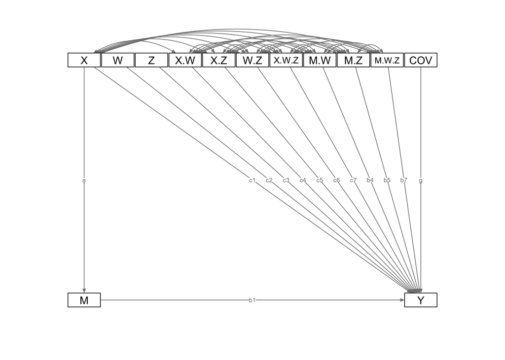

```r
# Plot model
library(semPlot)
plot = semPaths(Mod.Med.SEM, fixedStyle = 1, layout = "tree",
                  intercepts = F, label.scale=T, nCharNodes = 0,
                  sizeMan2=3, sizeMan=7, asize=2, residuals = F, exoCov = T)
```

# CLEAN UP

```r
# Clear environment
rm(list = ls())
```

```r
# Clear packages
p_unload(all)
```

```
## The following packages have been unloaded:
## semPlot, rmarkdown, corrplot, VIM, colorspace, mice, report, papaja, tinylabels, readxl, knitr, gridExtra, lavaan, psych, kableExtra, forcats, stringr, dplyr, purrr, readr, tidyr, tibble, ggplot2, tidyverse, pacman
```

```r
# Clear console
cat("\014")
```